# ML estimation with distcrete

Thibaut Jombart

2017-11-21

In this vignette, we illustrate how *distcrete* can be combined with classical optimisation procedures available in R to derive maximum-likelihood (ML) of parameters of distributions of interest. We simulate simple data from a discretised exponential distribution, and then attempt to recover the original parameters using ML.

## Simulating data

Simulating data from a discretised distribution is very easy using *distcrete*, as discretised distributions already contain a random variate generator in the `$r` component. We illustrate this by generating a discretised exponential distribution `x` with rate parameter 0.123:

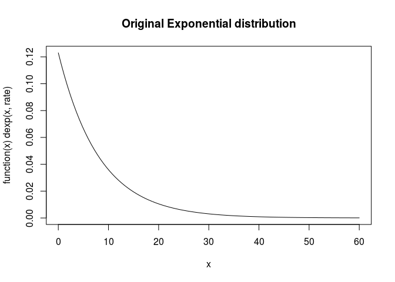

```r
library(distcrete)
rate <- 0.123
plot(function(x) dexp(x, rate), xlim = c(0, 60),
     main = "Original Exponential distribution")
```

```r
x <- distcrete("exp", interval = 1L, rate)
x$r
```

```
## function (n = 1)
## distcrete_r(d, n)
## <environment: 0x2c64e18>
```

We simulate 200 draws from the distribution `x`:

```r
set.seed(1)
sim <- x$r(200)
head(sim)
```

```
## [1]  3  4  7 19  2 19
```

```r
summary(sim)
```

```
##    Min. 1st Qu.  Median    Mean 3rd Qu.    Max.
##    0.00    3.00    6.00    8.07   11.00   40.00
```

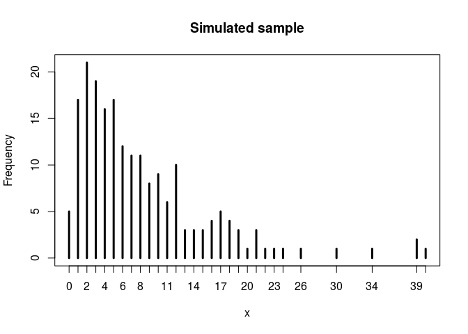

```r
plot(table(sim), lwd=3, xlab = "x", ylab = "Frequency",
     main = "Simulated sample")
```

## ML estimation

We will use the base function `optim` to find maximum likelihood estimates of the rate of the distribution `x`. The log-likelihood function to be optimised can be written as:

```r
ll <- function(param) {
    d <- distcrete("exp", interval = 1L, param)$d
    sum(d(sim, log = TRUE))
}
```

For instance, the log-likelihood with shapes and rates of 1.234 can be computed as:

```r
param <- c(rate = 1.234)
ll(param)
```

```
## [1] -1942.334
```

We can feed this function and initial parameters to `optimise`:

```r
opt <- optimise(ll, c(0, 20), maximum = TRUE)
opt
```

```
## $maximum
## [1] 0.1239829
##
## $objective
## [1] -621.1258
```

The ML estimate for the rate of the distribution is 0.1239829, which is close enough to the original value of 0.123.